# Visualisierung eines räumlichen Punktdatensatzes über ein gestrecktes Raster

Lukas Jungermann

Januar 2015

Zu Beginn wird der Workspace des Projektes ausgewählt und notwendige Bibliotheken eingelesen.

```r
setwd("/Users/lukasjungermann/Desktop/Uni/1 Semester MA/Data Management/W10-1")

library(sp)
library(raster)
library(rgdal)
library(RColorBrewer)
library(latticeExtra)
library(knitr)
```

Als Grundlage dienen zum einen Vektorpunkte der **BIS-Fogo Feldstudie (2014)** sowie ein Landsat Raster (Nov, 2014) der Insel Fogo, Kap Verde. Zu diesem Zweck werden die Daten direkt eingelesen und der Punktdatensatz mit dem gleichen Koordinatensystem wie der Rasterdatensatz transformiert.

```r
landsat.tif <- raster("LC82100502014328LGN00_B10.tif")
shp <- readOGR("data_2014_subset1.shp", "data_2014_subset1")
shp <- spTransform(shp, CRS(projection(landsat.tif)))
```

Im Anschluss wird die Plot-Funktion für beide Datensätze geschrieben. Hierbei werden zunächst die Klassen Vektorattribute definiert, die später auch die Legende bilden. Es wird eine einfache blaue Farbpalette definiert.

Danach wird die Ausdehnung des Rasters definiert, um es mit einem Rahmen plotten zu können. Sowohl die Vektorpuntkte, als auch das Raster werden mit dem Lattice Paket geplottet. Zur Darstellung des Landsat-Rasters werden 256 Graustufen verwendet.

Durch den Befehl “scales” kann dem Raster noch ein Koordinatensystem auf Basis seiner Ausdehnung angefügt werden, um eine entsprechende optische Raumreferenz für den Betrachter zu bieten.

Über den Befehl “as.layer()” kann ein Plot, dem anderen als Ebene hinzugefügt werden.

```r
layerFunction <- function (raster, vector){
classes <- cut(vector@data$COVRG, c(0, 20, 40, 60, 80, 100, 120))
shp_colors <- colorRampPalette(brewer.pal(6,"Blues"))(6)


min <- max(mean(getValues(raster)) - sd(getValues(raster)), 0)
max <- mean(getValues(raster)) + sd(getValues(raster))

breaks <- seq(min, max, length.out = 256)
yat = seq(extent(raster)@ymin,
                extent(raster)@ymax, length.out = 5)
xat = seq(extent(raster)@xmin,
                extent(raster)@xmax, length.out = 5)



plot1 <- spplot(raster, col.regions = gray.colors(256), at = breaks,
       key = list(space = 'left', text = list(levels(classes)),
                     points = list(pch = 21, cex = 2, fill = shp_colors)),
       colorkey=list(space="right"),
       panel = function(...){
         panel.levelplot(...)
         panel.abline(h = yat, v = xat, col = "grey0", lwd = 0.8, lty = 3)
         },
         scales = list(x = list(at = xat),
                     y = list(at = yat)))


plot2 <- spplot(vector, zcol = "COVRG", col.regions = shp_colors,
              cuts = c(0, 20, 40, 60, 80, 100, 120))

plot1 + as.layer(plot2)
}
```

Zuletzt müssen der Funktion nur noch die Datensätze übergeben werden.

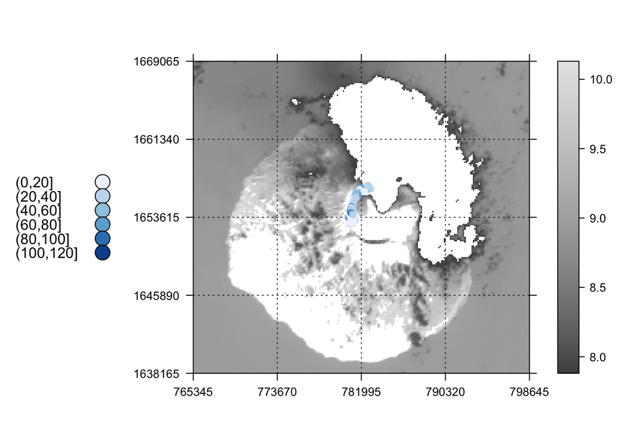

```r
layerFunction(landsat.tif, shp)
```